# Time Complexity of Algorithms

let’s assume that we all know what is the subject of this presentation. In the following we are going to watch how deciding on type of our algorithm can make difference in run time of our algorithm. I suggest if you don’t know the main idea just google the main title of this page.

#### first let’s see a complexity chart

I wanted to hide the code for creating this plot but sometimes I don’t feel like being humble. so :

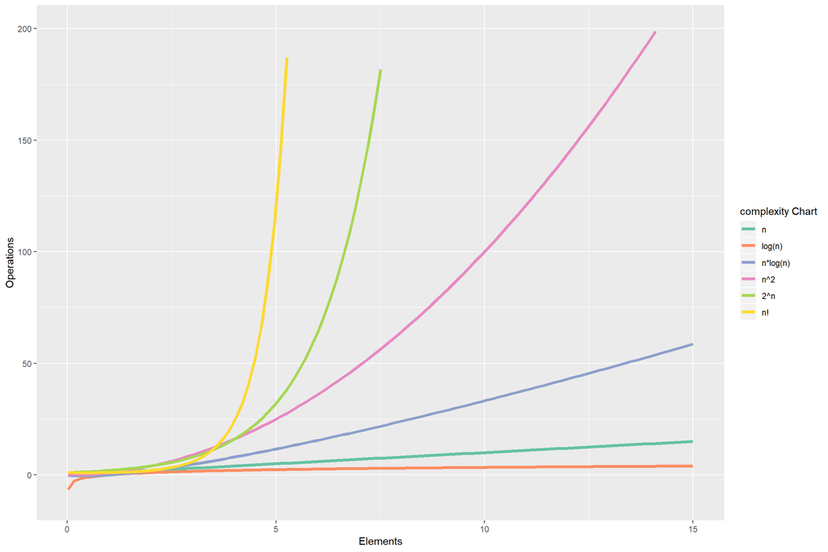

```r
library(ggplot2) ; library(RColorBrewer)
xd <- data.frame(x = c(0.01, 15))
cl <- brewer.pal(n = 6,name = 'Set2')

g <- ggplot(data = xd, aes(x = x))
g <- g + stat_function(fun = n , size = 1.5, aes(color = cl[1])) +
      stat_function(fun = logn , size = 1.5, aes(color = cl[2])) +
      stat_function(fun = nlogn , size = 1.5, aes(color = cl[3])) +
      stat_function(fun = n2, size = 1.5, aes(color = cl[4])) +
      stat_function(fun = pow2n , size = 1.5, aes(color = cl[5])) +
      stat_function(fun = factn , size = 1.5, aes(color = cl[6]))
g <- g + scale_color_identity(
      name = 'complexity Chart',
      breaks = cl,
      labels = c('n', 'log(n)', 'n*log(n)', 'n^2', '2^n', 'n!'),
      guide = 'legend'
)
g <- g + ylim(c(-10, 200))
g <- g + labs(x = 'Elements',y ='Operations')
g
```

## O( $\log n$ ) | Binary Search

in this section an algorithm with Big-O of level log(n) will be explained and simulated.

binary search is one of the fastest algorithms which has some assumptions. let’s take a look at this GIF :

[figure not shown]

I believe this image prepared us for jumping into codeing section but before that let’s declare or assumptions:

- the array we pass to our function *must* be **sorted** in an ascending way. why? think about we we’re going to measure
- another assumption is our target element is inside the array

```r
bin_search <- function (v, t) {
      lo <- 1
      hi <- length(v)
      while (lo <= hi) {
            mid = round((lo + hi) / 2)

            if (abs(v[mid] - t) <= 0 ) {
                  return(mid)
                  break
            } else if (v[mid] < t) {
                  lo = mid + 1
            } else {
                  hi = mid - 1
            }
      }
}
```

```r
test_array <- seq(from = 7,to = 2100,by = 7)
test_array[276]
```

```
## [1] 1932
```

so we want to find out whether the function outputs 276 when we pass 1932 to it or not. we’ll see:

```r
bin_search(v = test_array,t = 1932)
```

```
## [1] 276
```

looks like our function works properly. now it’s time for

### Simulation

in order to report a rather precise number I couldn’t use R language’s built in function which is named `{r} Sys.time()` so I went through an advanced package named microbenchmark. I used **uniform distribution** for creating random numbers and I ran my time measuring for 50 times in order to have more coherent data.

```r
library(microbenchmark)
set.seed(12345)
df <- microbenchmark(
bin2   =  bin_search(v = seq(1,100),t = round(runif(1,min = 1,max = 100))),
bin3 =  bin_search(v = seq(1,1000),t = round(runif(1,min = 1,max = 1000))),
bin4   =  bin_search(v = seq(1,10000),t = round(runif(1,min = 1,max = 10000))),
bin5 =  bin_search(v = seq(1,100000),t = round(runif(1,min = 1,max = 100000))),
bin6   =  bin_search(v = seq(1,1000000),t = round(runif(1,min = 1,max = 1000000))),
times = 50,unit = 'ms')

df
```

```
## Unit: milliseconds
##  expr      min       lq       mean    median       uq      max neval
##  bin2 0.009440 0.012838 0.01479414 0.0134045 0.014348 0.068720    50
##  bin3 0.010950 0.015104 0.01655370 0.0162360 0.016615 0.036626    50
##  bin4 0.015104 0.018124 0.01964248 0.0192570 0.019635 0.035116    50
##  bin5 0.016236 0.020767 0.02136408 0.0215225 0.022278 0.030207    50
##  bin6 0.011328 0.023033 0.02457356 0.0241660 0.024921 0.038136    50
```

and finally plots of these numbers :

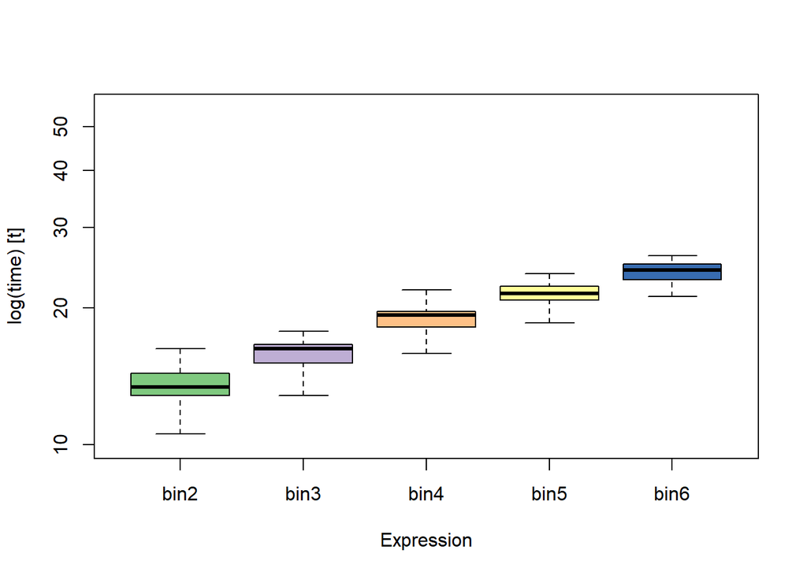

```r
cl2 <- brewer.pal(name = 'Accent', n =6)
boxplot(df,col = cl2,log = T,outline = F,ylime = c(10,55))
```

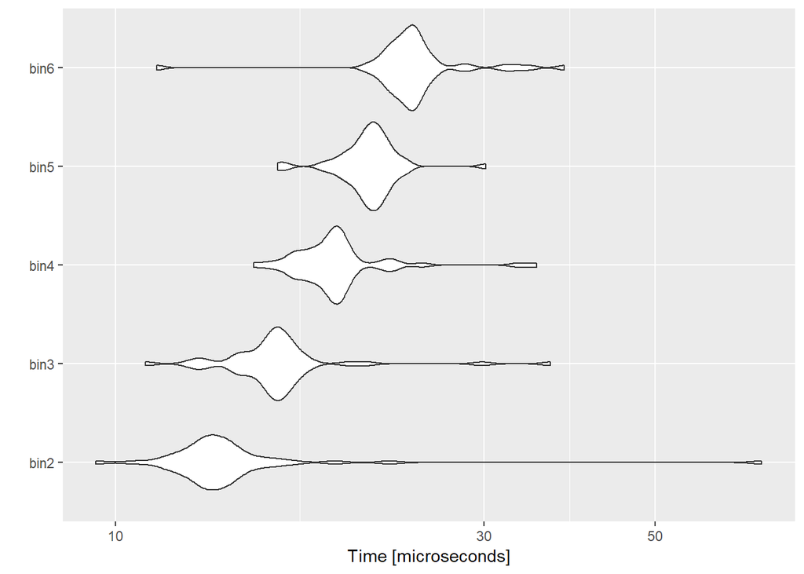

```r
autoplot(df)
```

## O(n) | linear search

as an example of linear search I’m going to implement **linear search** which which is a loop over an array to find the target.

```r
ls <- function(v,t){
      c = F
      l <- length(v)
      for (i in 1:l){
            if (v[i] == t){
                  return(i)
                  c = T
            }
      }
      if (c == F){
            return('Not in Vector')
      }
}
```

it was an easy one. let’s test it.

```r
vector_test <- seq(1,700,by = 2)
target <- 451
ans <- ls(vector_test,target)
ans
```

```
## [1] 226
```

doing double check :

```r
vector_test[ans]
```

```
## [1] 451
```

it works. so now we can jump to simulation: I’m going to repeat what we did for binary search.so I just hide the code for simulation.

```r
library(microbenchmark)
set.seed(12345)
df1 <- microbenchmark(
bin2   =  ls(v = seq(1,100),t = round(runif(1,min = 1,max = 100))),
bin3   =  ls(v = seq(1,1000),t = round(runif(1,min = 1,max = 1000))),
bin4   =  ls(v = seq(1,10000),t = round(runif(1,min = 1,max = 10000))),
bin5   =  ls(v = seq(1,100000),t = round(runif(1,min = 1,max = 100000))),
bin6   =  ls(v = seq(1,1000000),t = round(runif(1,min = 1,max = 1000000))),
times = 50,unit = 'ms')

df1
```

```
## Unit: milliseconds
##  expr      min        lq        mean     median        uq       max neval
##  bin2 0.009441  0.013216  0.02933860  0.0164250  0.047576  0.129888    50
##  bin3 0.013971  0.033606  0.06663614  0.0534285  0.085333  0.535788    50
##  bin4 0.036626  0.181617  0.30177878  0.3084845  0.396461  0.819352    50
##  bin5 0.090620  1.298502  2.64879396  2.8297835  3.830563  6.105491    50
##  bin6 0.208426 11.828113 27.11919090 27.5436150 42.994809 59.282913    50
```

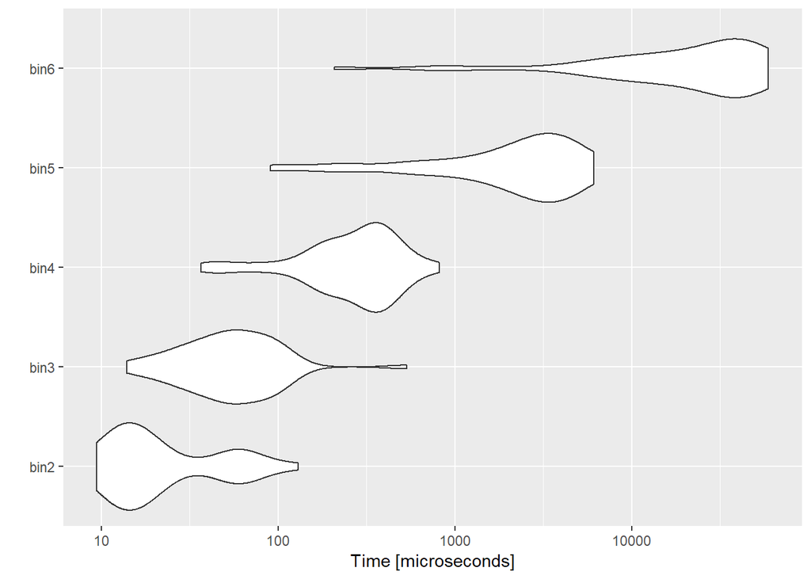

```r
autoplot(df1)
```